# pca

### Ejercicio para entrar en calor

```r
library(FactoMineR)
library(factoextra)
library(xtable)

class(decathlon2)
decathlon2.active <- decathlon2[1:27, 1:10]
head(decathlon2.active)
```

'data.frame'

A data.frame: 6 × 10

|  | X100m <dbl> | Long.jump <dbl> | Shot.put <dbl> | High.jump <dbl> | X400m <dbl> | X110m.hurdle <dbl> | Discus <dbl> | Pole.vault <dbl> | Javeline <dbl> | X1500m <dbl> |
| --- | --- | --- | --- | --- | --- | --- | --- | --- | --- | --- |
| SEBRLE | 11.04 | 7.58 | 14.83 | 2.07 | 49.81 | 14.69 | 43.75 | 5.02 | 63.19 | 291.7 |
| CLAY | 10.76 | 7.40 | 14.26 | 1.86 | 49.37 | 14.05 | 50.72 | 4.92 | 60.15 | 301.5 |
| BERNARD | 11.02 | 7.23 | 14.25 | 1.92 | 48.93 | 14.99 | 40.87 | 5.32 | 62.77 | 280.1 |
| YURKOV | 11.34 | 7.09 | 15.19 | 2.10 | 50.42 | 15.31 | 46.26 | 4.72 | 63.44 | 276.4 |
| ZSIVOCZKY | 11.13 | 7.30 | 13.48 | 2.01 | 48.62 | 14.17 | 45.67 | 4.42 | 55.37 | 268.0 |
| McMULLEN | 10.83 | 7.31 | 13.76 | 2.13 | 49.91 | 14.38 | 44.41 | 4.42 | 56.37 | 285.1 |

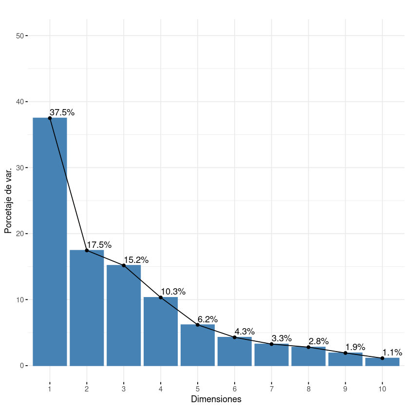

```r
## Calculamos las PCA

res.pca <- PCA(decathlon2.active, graph = FALSE)

# Grafico autovalores
fviz_eig(res.pca, addlabels = TRUE, ylim = c(0, 50), main="", xlab="Dimensiones", ylab="Porcetaje de var.")
```

```r
# Contribución de la variable a la componente
res.pca$var$contrib
```

A matrix: 10 × 5 of type dbl

|  | Dim.1 | Dim.2 | Dim.3 | Dim.4 | Dim.5 |
| --- | --- | --- | --- | --- | --- |
| X100m | 17.8849964 | 6.7327182 | 0.670277238 | 0.9949816 | 7.819960 |
| Long.jump | 15.3581652 | 8.3394260 | 0.002582856 | 3.3309545 | 11.256195 |
| Shot.put | 13.6357518 | 4.5605826 | 14.793387670 | 0.1262838 | 12.566155 |
| High.jump | 9.8737797 | 21.4165036 | 0.001397716 | 0.4917303 | 14.623936 |
| X400m | 11.0544924 | 1.2622988 | 17.525552828 | 7.0513559 | 6.424985 |
| X110m.hurdle | 13.6869799 | 5.0732713 | 11.426291715 | 2.4733503 | 4.196517 |
| Discus | 13.7048617 | 2.3939535 | 4.814385760 | 15.3171947 | 18.654551 |
| Pole.vault | 1.3073595 | 31.1704550 | 10.704533859 | 6.1303166 | 11.160666 |
| Javeline | 3.3640178 | 0.5562982 | 31.863162259 | 22.8412641 | 2.881255 |
| X1500m | 0.1295955 | 18.4944926 | 8.198428099 | 41.2425682 | 10.415780 |

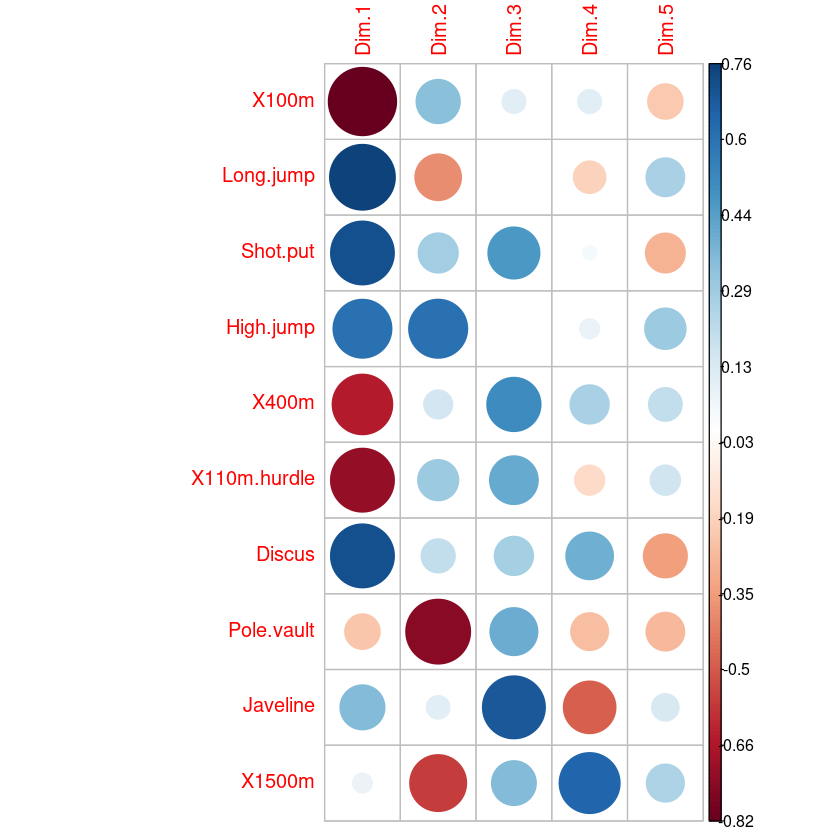

```r
# Correlacion entre variables y componentes

library("corrplot")
corrplot(res.pca$var$cor, is.corr=FALSE)
```

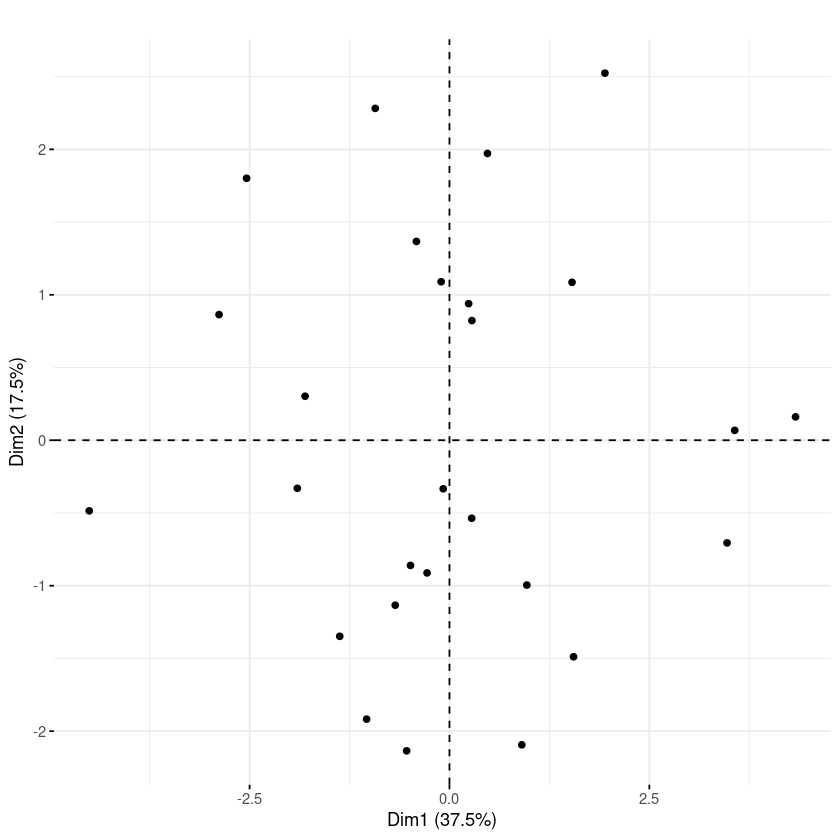

```r
# Gráfico de las proyecciones de los datos a las dos primeras componentes

fviz_pca_ind(res.pca, title="", geom="point")
```

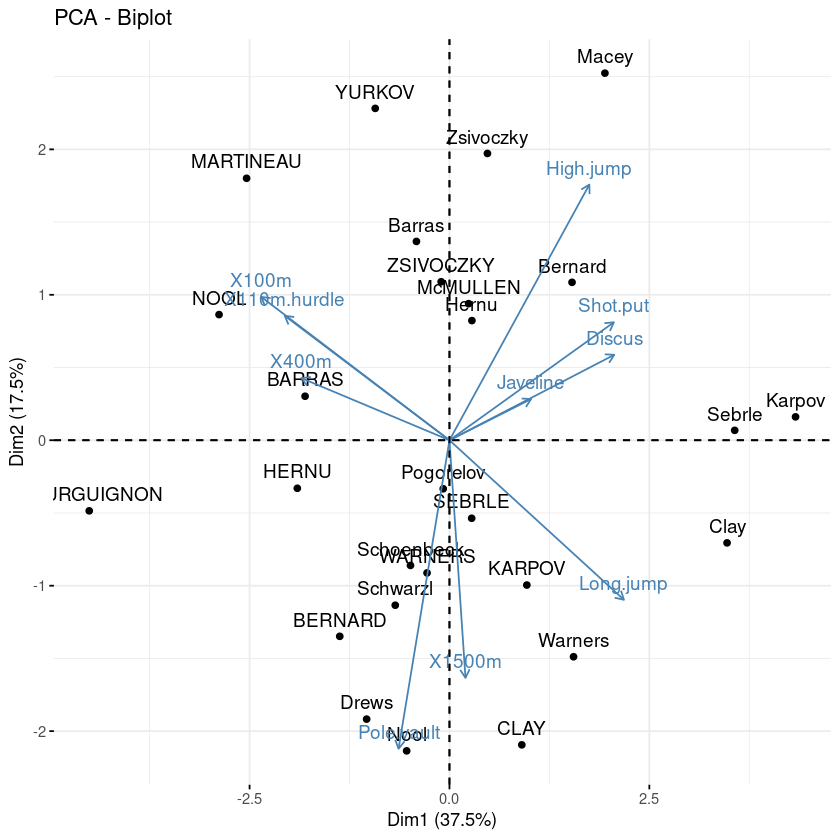

```r
# Biplot

fviz_pca_biplot(res.pca)
```

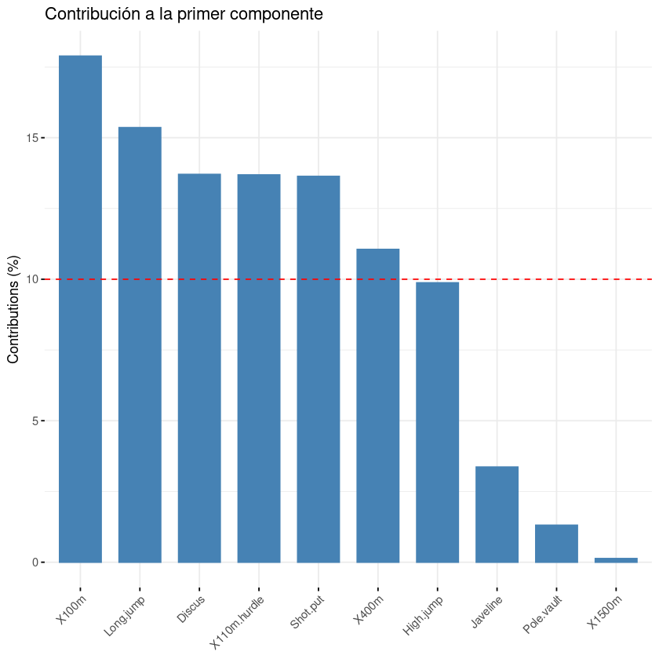

```r
# Gráfico contribución de las variables a la primer componente

fviz_contrib(res.pca, choice = "var", axes = 1, top = 10, title="Contribución a la primer componente")
```

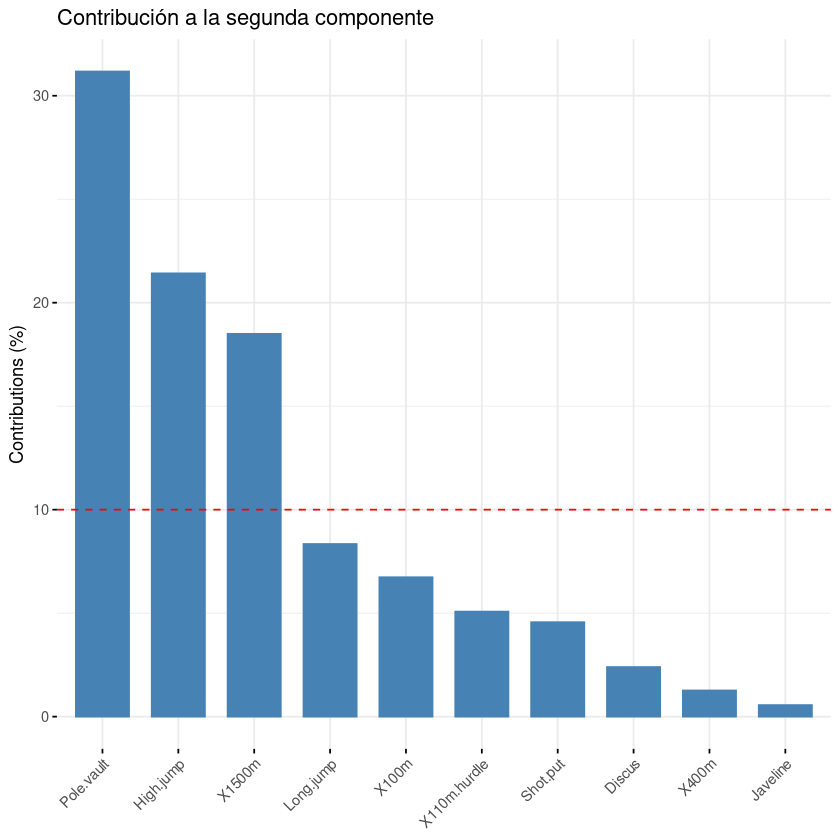

```r
# Gráfico contribución de las variables a la segunda componente

fviz_contrib(res.pca, choice = "var", axes = 2, top = 10, title="Contribución a la segunda componente")
```

## Ejercicio: conceptual

- Generar una muestra de vectores aleatorios de tamaño 20 con distrbución $N_2(\mu, \Sigma),$ con $\mu=c(0,0)$ y $\Sigma = I_2.$ ¿Quiénes son las componentes principales?
- Generar una muestra como la anterior, pero utilizar $\Sigma = \begin{pmatrix} 2 & 1.2 \\ 1.2 & 1 \end{pmatrix}.$ Calcular los autovectores de $\Sigma$ y dar las componentes muestrales. graficar los datos y los autovectores. Añadir al mismo gráfico los datos proyectados en el primer componente y proyectados a las segunda componente (sugerencia: usar la funcion eigen).
- Generar una muestra aleatoria de tamaño 50 con matriz de covarianza diagonal tal que el primer autovector se corresponda con el 90% de variabilidad de la muestra medida como la traza de sigma. Una vez logrado el primer objetivo poner un outlier en la dirección del segundo autovector y calcular las pca.
- Hacer lo mismo para el conjunto de datos *sat.csv*.

## Ejercicio: reducción de dimensión 1

Utilizar las componentes principales como técnica de reducción de dimensión algún conjunto de datos que utilizaron en Aprendizaje Supervisado. Hacer un ligero análisis y combinar con una técnica de clasificación. Comparar con la misma técnica sin utilizar la reducción. Sugerencia: si utilizó un algoritmo muy complicado, es preferible que baje un poco la complejidad para poder comparar razonablemente.

## Ejercicio: reducción de dimensión 2

Para los datasets que estuvimos trabajando utilizar PCA para poder dibujar. Recuerde que reducir la dimensión puede ser una buena forma de visualizar los clusters.

## Ejercicio: reducción de dimensión 3

Hacer un análisis de reducción de dimensión al conjunto de datos *sat.csv*.